# Institutional-Grade Zinc Price Forecasting (1990-2025)

Data Science Research

March 11, 2026

## Executive Summary

This RPubs report translates the source study (`asc_ceny_cynku.pdf`) into an English and reproducible workflow.

This iteration is focused on Chapter I and mirrors the original structure:

- 1.1 Data description,
- 1.2 Time-series decomposition,
- 1.3 ARIMA model (stationarity, identification and validation, forecasting),
- 1.4 Extrapolative model benchmark.

## I. Non-Seasonal Series

### 1.1 Data Description

The dataset contains monthly zinc prices in USD per metric ton. The source report states 423 observations from January 1990 to March 2025. We verify this directly below.

```r
raw_data <- readr::read_csv("zinc_prices.csv", show_col_types = FALSE)

zinc_df <- raw_data %>%
  transmute(
    date = as.Date(paste0("01-", Date), format = "%d-%b-%y"),
    price = as.numeric(gsub(",", ".", gsub("\\s+", "", Price)))
  ) %>%
  arrange(date) %>%
  mutate(log_price = log(price))

if (anyNA(zinc_df$date) || anyNA(zinc_df$price)) {
  stop("Date or price parsing generated missing values.")
}
if (any(zinc_df$price <= 0)) {
  stop("Non-positive prices detected. Log transformation is invalid.")
}
if (n_distinct(zinc_df$date) != nrow(zinc_df)) {
  stop("Duplicate monthly timestamps detected.")
}

start_year <- as.integer(format(min(zinc_df$date), "%Y"))
start_month <- as.integer(format(min(zinc_df$date), "%m"))

price_ts <- ts(zinc_df$price, start = c(start_year, start_month), frequency = 12)
log_price_ts <- ts(zinc_df$log_price, start = c(start_year, start_month), frequency = 12)
```

```r
qa_table <- tibble(
  metric = c(
    "Observations",
    "Start date",
    "End date",
    "Missing dates",
    "Missing prices",
    "Duplicate dates"
  ),
  value = c(
    nrow(zinc_df),
    as.character(min(zinc_df$date)),
    as.character(max(zinc_df$date)),
    sum(is.na(zinc_df$date)),
    sum(is.na(zinc_df$price)),
    nrow(zinc_df) - n_distinct(zinc_df$date)
  )
)

knitr::kable(qa_table, caption = "Table 1. Input data quality checks")
```

Table 1. Input data quality checks

| metric | value |
| --- | --- |
| Observations | 423 |
| Start date | 1990-01-01 |
| End date | 2025-03-01 |
| Missing dates | 0 |
| Missing prices | 0 |
| Duplicate dates | 0 |

**Interpretation (1.1):** The sample contains 423 monthly observations from 1990-01-01 to 2025-03-01, fully consistent with the source report. There are no missing values and no duplicate timestamps.

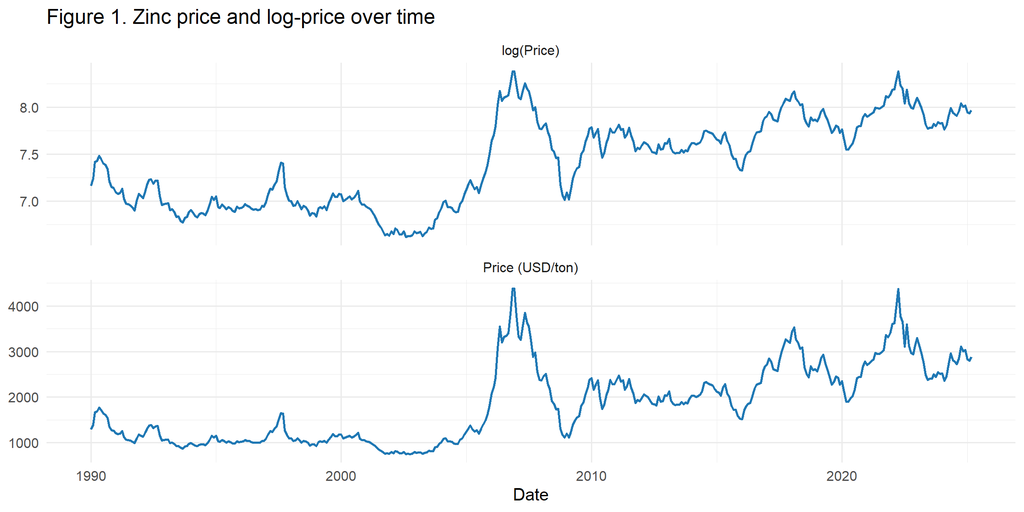

```r
plot_df <- zinc_df %>%
  select(date, price, log_price) %>%
  pivot_longer(cols = c(price, log_price), names_to = "series", values_to = "value") %>%
  mutate(
    series = recode(
      series,
      price = "Price (USD/ton)",
      log_price = "log(Price)"
    )
  )

ggplot(plot_df, aes(x = date, y = value)) +
  geom_line(color = "#1f78b4", linewidth = 0.8) +
  facet_wrap(~series, scales = "free_y", ncol = 1) +
  labs(
    title = "Figure 1. Zinc price and log-price over time",
    x = "Date",
    y = NULL
  ) +
  theme_minimal(base_size = 12)
```

**Interpretation (Figure 1):** The series shows strong cyclical commodity behavior and larger volatility amplitude in later years. The log transformation reduces heteroskedasticity and supports model-based inference.

### 1.2 Time-Series Decomposition

The source report uses Demetra/TRAMO-SEATS and concludes that seasonality is not material. In RPubs, we mirror that logic with an STL proxy and compare original versus seasonally adjusted series.

```r
stl_fit <- stl(log_price_ts, s.window = "periodic", robust = TRUE)

seasonally_adjusted_log <- forecast::seasadj(stl_fit)
seasonally_adjusted_price <- exp(as.numeric(seasonally_adjusted_log))

decomp_df <- tibble(
  date = zinc_df$date,
  original_price = zinc_df$price,
  sa_price = seasonally_adjusted_price
)

seasonality_strength <- max(
  0,
  1 - var(stl_fit$time.series[, "remainder"], na.rm = TRUE) /
    var(stl_fit$time.series[, "remainder"] + stl_fit$time.series[, "seasonal"], na.rm = TRUE)
)

decomp_summary <- tibble(
  metric = c(
    "Seasonality strength (0 to 1)",
    "Correlation original vs seasonally adjusted"
  ),
  value = c(
    round(seasonality_strength, 4),
    round(cor(decomp_df$original_price, decomp_df$sa_price), 4)
  )
)

knitr::kable(decomp_summary, caption = "Table 2. Decomposition diagnostics")
```

Table 2. Decomposition diagnostics

| metric | value |
| --- | --- |
| Seasonality strength (0 to 1) | 0.0000 |
| Correlation original vs seasonally adjusted | 0.9994 |

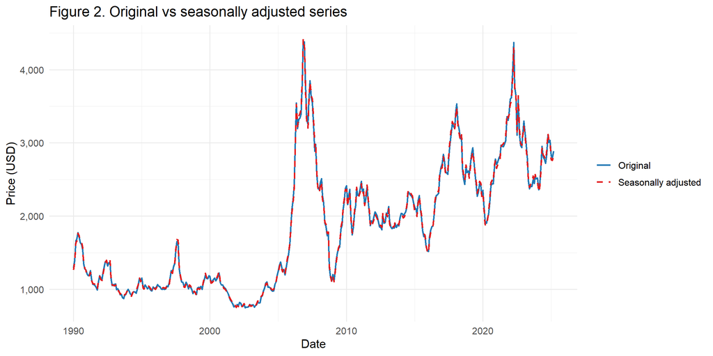

```r
ggplot(decomp_df, aes(x = date)) +
  geom_line(aes(y = original_price, color = "Original"), linewidth = 0.8) +
  geom_line(aes(y = sa_price, color = "Seasonally adjusted"), linewidth = 0.8, linetype = "dashed") +
  scale_color_manual(values = c("Original" = "#1f78b4", "Seasonally adjusted" = "#e31a1c")) +
  scale_y_continuous(labels = scales::comma) +
  labs(
    title = "Figure 2. Original vs seasonally adjusted series",
    x = "Date",
    y = "Price (USD)",
    color = NULL
  ) +
  theme_minimal(base_size = 12)
```

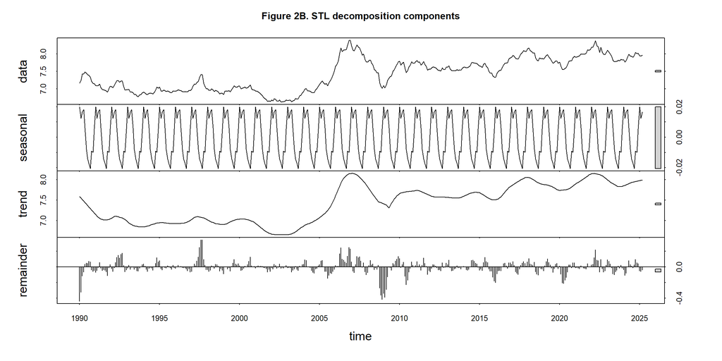

```r
plot(stl_fit, main = "Figure 2B. STL decomposition components")
```

**Interpretation (1.2):** Estimated seasonality is weak (0), and the adjusted series is almost identical to the original (0.9994). This matches the source report conclusion that the analyzed zinc series is effectively non-seasonal.

### 1.3 ARIMA Model

#### 1.3.1 Stationarity

```r
lambda_guerrero <- forecast::BoxCox.lambda(price_ts, method = "guerrero")

boxcox_table <- tibble(
  diagnostic = "Guerrero Box-Cox lambda",
  value = round(lambda_guerrero, 3),
  interpretation = ifelse(
    abs(lambda_guerrero) < 0.2,
    "Near zero: log transform is justified",
    "Not near zero: alternative transform should be evaluated"
  )
)

knitr::kable(boxcox_table, caption = "Table 3. Variance stabilization diagnostic")
```

Table 3. Variance stabilization diagnostic

| diagnostic | value | interpretation |
| --- | --- | --- |
| Guerrero Box-Cox lambda | -0.121 | Near zero: log transform is justified |

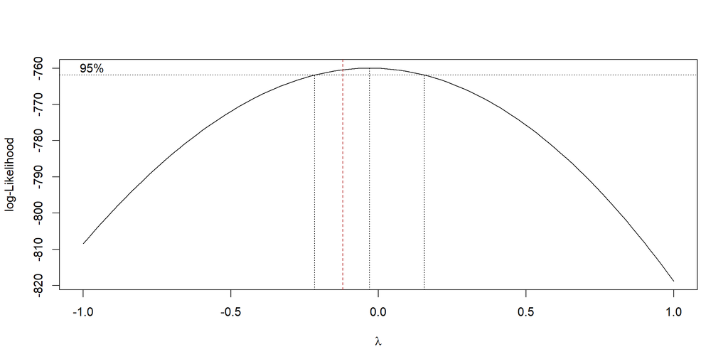

```r
price_clean <- na.omit(zinc_df$price)
time_index <- seq_along(price_clean)
boxcox_model <- lm(price_clean ~ time_index)

MASS::boxcox(
  boxcox_model,
  lambda = seq(-1, 1, 0.1),
  main = "Figure 3. Box-Cox profile for raw zinc price"
)
abline(v = lambda_guerrero, lty = 2, col = "firebrick")
```

```r
diff_log_price_ts <- diff(log_price_ts)

adf_level <- tseries::adf.test(log_price_ts, k = 12)
adf_diff <- tseries::adf.test(diff_log_price_ts, k = 12)

adf_table <- tibble(
  series = c("log(price)", "diff(log(price))"),
  statistic = c(unname(adf_level$statistic), unname(adf_diff$statistic)),
  p_value = c(adf_level$p.value, adf_diff$p.value)
)

knitr::kable(adf_table, digits = 4, caption = "Table 4. ADF diagnostics")
```

Table 4. ADF diagnostics

| series | statistic | p_value |
| --- | --- | --- |
| log(price) | -3.5546 | 0.0374 |
| diff(log(price)) | -5.6265 | 0.0100 |

```r
ur_level <- urca::ur.df(log_price_ts, type = "trend", selectlags = "AIC")
ur_diff <- urca::ur.df(diff_log_price_ts, type = "drift", selectlags = "AIC")

extract_ur <- function(model, label) {
  test_name <- names(model@teststat)[1]
  tibble(
    series = label,
    test = test_name,
    statistic = unname(model@teststat[1]),
    critical_1pct = unname(model@cval[1, "1pct"]),
    critical_5pct = unname(model@cval[1, "5pct"]),
    critical_10pct = unname(model@cval[1, "10pct"]),
    selected_lags = model@lags
  )
}

ur_table <- bind_rows(
  extract_ur(ur_level, "log(price)"),
  extract_ur(ur_diff, "diff(log(price))")
)

knitr::kable(ur_table, digits = 4, caption = "Table 5. ur.df diagnostics")
```

Table 5. ur.df diagnostics

| series | statistic | critical_1pct | critical_5pct | critical_10pct | selected_lags |
| --- | --- | --- | --- | --- | --- |
| log(price) | -3.1268 | -3.98 | -3.42 | -3.13 | 1 |
| diff(log(price)) | -12.2519 | -3.44 | -2.87 | -2.57 | 1 |

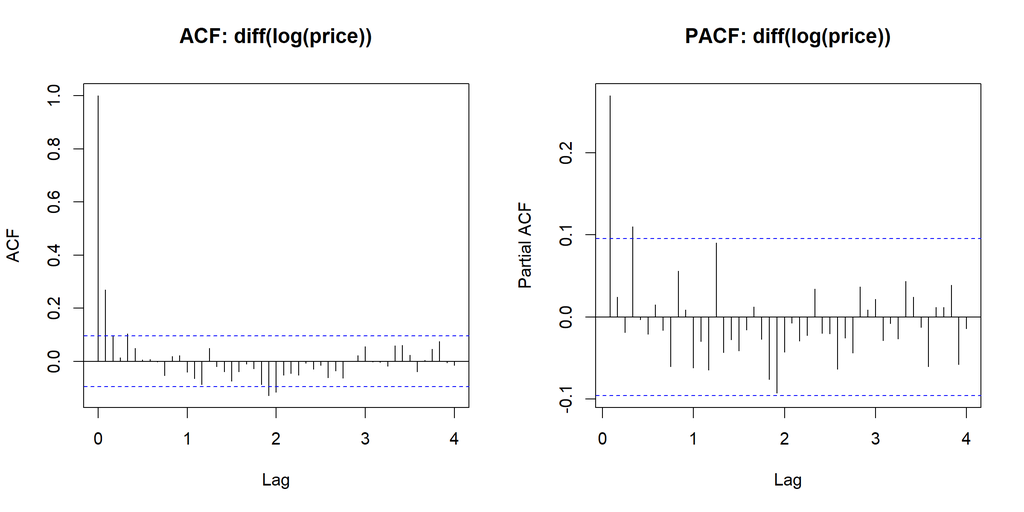

```r
old_par <- par(no.readonly = TRUE)
par(mfrow = c(1, 2))
acf(diff_log_price_ts, lag.max = 48, main = "ACF: diff(log(price))")
pacf(diff_log_price_ts, lag.max = 48, main = "PACF: diff(log(price))")
```

```r
par(old_par)
```

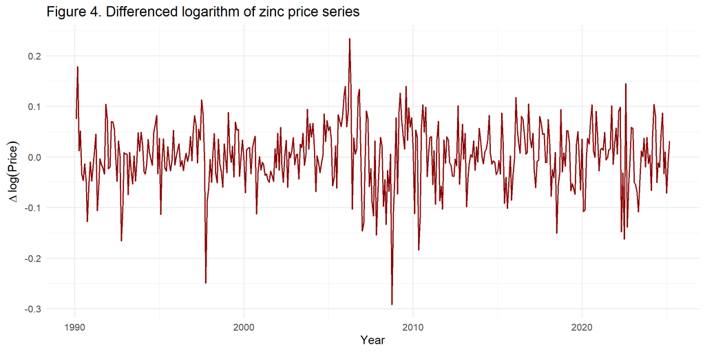

```r
diff_series_df <- tibble(
  date = zinc_df$date[-1],
  diff_log = as.numeric(diff_log_price_ts)
)

ggplot(diff_series_df, aes(x = date, y = diff_log)) +
  geom_line(color = "darkred", linewidth = 0.7) +
  labs(
    title = "Figure 4. Differenced logarithm of zinc price series",
    x = "Year",
    y = expression(Delta ~ log(Price))
  ) +
  theme_minimal(base_size = 12)
```

**Interpretation (1.3.1):** The Box-Cox diagnostics (Table 3 and Figure 3) support log transformation (`lambda = -0.121). The differenced log series is clearly stationary (`ADF p-value = 0.01), supporting ARIMA with one differencing order (`d = 1`).

#### 1.3.2 Identification and Validation

```r
h <- 12
n <- length(log_price_ts)

if (n <= h) {
  stop("Not enough observations for a 12-month holdout split.")
}

train_log <- ts(
  head(as.numeric(log_price_ts), n - h),
  start = start(log_price_ts),
  frequency = 12
)

test_log <- tail(as.numeric(log_price_ts), h)
test_dates <- tail(zinc_df$date, h)
```

```r
candidate_orders <- tibble(
  model = c("ARIMA(1,1,1)", "ARIMA(1,1,2)", "ARIMA(4,1,1)", "ARIMA(4,1,2)"),
  p = c(1, 1, 4, 4),
  d = c(1, 1, 1, 1),
  q = c(1, 2, 1, 2)
)

calc_metrics <- function(actual, predicted) {
  tibble(
    MAE = mean(abs(actual - predicted)),
    RMSE = sqrt(mean((actual - predicted)^2)),
    MAPE = mean(abs(actual - predicted) / pmax(abs(actual), 1e-8)) * 100,
    sMAPE = mean(200 * abs(actual - predicted) / (abs(actual) + abs(predicted) + 1e-8))
  )
}

safe_arima <- purrr::possibly(
  function(p, d, q) {
    forecast::Arima(train_log, order = c(p, d, q), include.drift = TRUE)
  },
  otherwise = NULL
)

model_results <- candidate_orders %>%
  mutate(fit = pmap(list(p, d, q), safe_arima)) %>%
  filter(!map_lgl(fit, is.null)) %>%
  mutate(
    fc = map(fit, forecast::forecast, h = h),
    metrics = map(fc, ~calc_metrics(test_log, as.numeric(.x$mean))),
    AIC = map_dbl(fit, AIC),
    BIC = map_dbl(fit, BIC),
    logLik = map_dbl(fit, ~as.numeric(logLik(.x))),
    Ljung_Box_p = map_dbl(
      fit,
      ~Box.test(
        residuals(.x),
        lag = 24,
        type = "Ljung-Box",
        fitdf = length(coef(.x))
      )$p.value
    )
  ) %>%
  unnest(metrics) %>%
  arrange(RMSE, AIC)

if (nrow(model_results) == 0) {
  stop("No ARIMA specification converged on the training window.")
}

knitr::kable(
  model_results %>%
    select(model, AIC, BIC, logLik, MAE, RMSE, MAPE, sMAPE, Ljung_Box_p),
  digits = 4,
  caption = "Table 6. ARIMA candidate comparison"
)
```

Table 6. ARIMA candidate comparison

| model | AIC | BIC | logLik | MAE | RMSE | MAPE | sMAPE | Ljung_Box_p |
| --- | --- | --- | --- | --- | --- | --- | --- | --- |
| ARIMA(1,1,1) | -1135.490 | -1119.425 | 571.7450 | 0.1325 | 0.1383 | 1.6618 | 1.6769 | 0.2620 |
| ARIMA(1,1,2) | -1133.778 | -1113.697 | 571.8889 | 0.1337 | 0.1394 | 1.6760 | 1.6914 | 0.2582 |
| ARIMA(4,1,2) | -1134.124 | -1101.995 | 575.0619 | 0.1351 | 0.1408 | 1.6947 | 1.7104 | 0.4291 |
| ARIMA(4,1,1) | -1134.824 | -1106.711 | 574.4121 | 0.1360 | 0.1415 | 1.7056 | 1.7214 | 0.4560 |

```r
best_row <- model_results %>% slice(1)
best_model_name <- best_row$model[[1]]
best_fit <- best_row$fit[[1]]
best_holdout_fc <- best_row$fc[[1]]

best_lb <- Box.test(
  residuals(best_fit),
  lag = 24,
  type = "Ljung-Box",
  fitdf = length(coef(best_fit))
)

best_model_table <- tibble(
  selected_model = best_model_name,
  holdout_rmse_log = round(as.numeric(best_row$RMSE), 4),
  holdout_mape_log = round(as.numeric(best_row$MAPE), 4),
  residual_ljung_box_p = round(best_lb$p.value, 4)
)

knitr::kable(best_model_table, caption = "Table 7. Selected ARIMA diagnostics")
```

Table 7. Selected ARIMA diagnostics

| selected_model | holdout_rmse_log | holdout_mape_log | residual_ljung_box_p |
| --- | --- | --- | --- |
| ARIMA(1,1,1) | 0.1383 | 1.6618 | 0.262 |

**Interpretation (1.3.2):** The selected specification is **ARIMA(1,1,1)**. Residual diagnostics are acceptable (`Ljung-Box p-value = 0.262), so the model is retained for forecasting.

#### 1.3.3 Forecasting

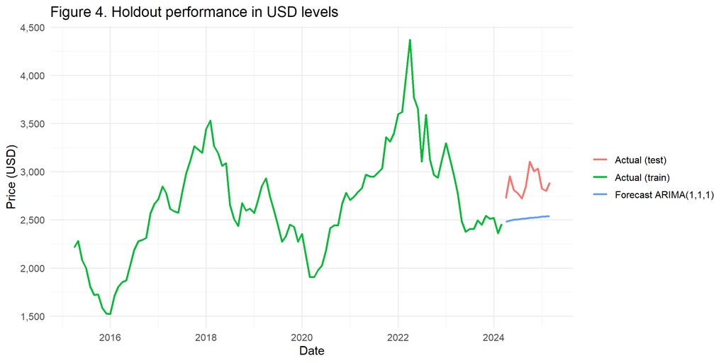

```r
plot_start_date <- if (nrow(zinc_df) > 120) {
  zinc_df$date[nrow(zinc_df) - 119]
} else {
  min(zinc_df$date)
}

holdout_df <- bind_rows(
  zinc_df %>%
    slice(1:(nrow(zinc_df) - h)) %>%
    transmute(date, value = price, series = "Actual (train)"),
  zinc_df %>%
    slice((nrow(zinc_df) - h + 1):n()) %>%
    transmute(date, value = price, series = "Actual (test)"),
  tibble(
    date = test_dates,
    value = exp(as.numeric(best_holdout_fc$mean)),
    series = paste0("Forecast ", best_model_name)
  )
) %>%
  filter(date >= plot_start_date)

ggplot(holdout_df, aes(x = date, y = value, color = series)) +
  geom_line(linewidth = 0.9) +
  scale_y_continuous(labels = scales::comma) +
  labs(
    title = "Figure 4. Holdout performance in USD levels",
    x = "Date",
    y = "Price (USD)",
    color = NULL
  ) +
  theme_minimal(base_size = 12)
```

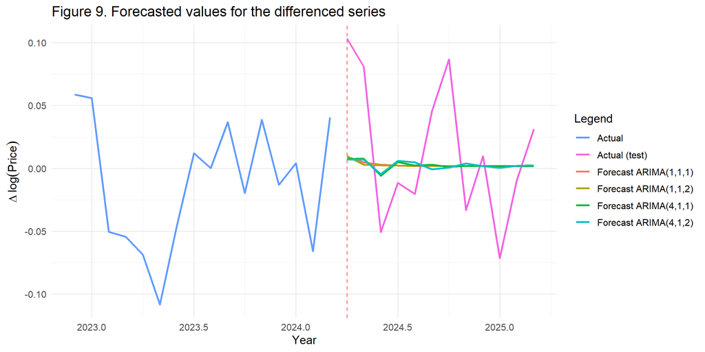

```r
as_year_decimal <- function(d) {
  y <- as.integer(format(d, "%Y"))
  m <- as.integer(format(d, "%m"))
  y + (m - 1) / 12
}

fc_by_model <- purrr::set_names(model_results$fc, model_results$model)

train_log_vec <- as.numeric(train_log)
test_log_vec <- as.numeric(test_log)
last_train_log <- tail(train_log_vec, 1)

actual_test_diff <- c(test_log_vec[1] - last_train_log, diff(test_log_vec))
train_diff <- diff(train_log_vec)
train_diff_dates <- zinc_df$date[2:(length(train_log_vec))]

train_tail_len <- min(16, length(train_diff))

diff_forecast_df <- bind_rows(
  tibble(
    date = tail(train_diff_dates, train_tail_len),
    value = tail(train_diff, train_tail_len),
    series = "Actual"
  ),
  tibble(
    date = test_dates,
    value = actual_test_diff,
    series = "Actual (test)"
  ),
  purrr::imap_dfr(fc_by_model, function(fc_obj, model_name) {
    pred_log <- as.numeric(fc_obj$mean)
    pred_diff <- c(pred_log[1] - last_train_log, diff(pred_log))
    tibble(
      date = test_dates,
      value = pred_diff,
      series = paste("Forecast", model_name)
    )
  })
) %>%
  mutate(year_num = as_year_decimal(date))

diff_colors <- c(
  "Forecast ARIMA(1,1,1)" = "#F8766D",
  "Forecast ARIMA(1,1,2)" = "#B79F00",
  "Forecast ARIMA(4,1,1)" = "#00BA38",
  "Forecast ARIMA(4,1,2)" = "#00BFC4",
  "Actual" = "#619CFF",
  "Actual (test)" = "#F564E3"
)

ggplot(diff_forecast_df, aes(x = year_num, y = value, color = series)) +
  geom_line(linewidth = 0.9) +
  geom_vline(xintercept = as_year_decimal(min(test_dates)), linetype = "dashed", color = "#F8766D") +
  scale_color_manual(values = diff_colors) +
  labs(
    title = "Figure 9. Forecasted values for the differenced series",
    x = "Year",
    y = expression(Delta ~ log(Price)),
    color = "Legend"
  ) +
  theme_minimal(base_size = 12)
```

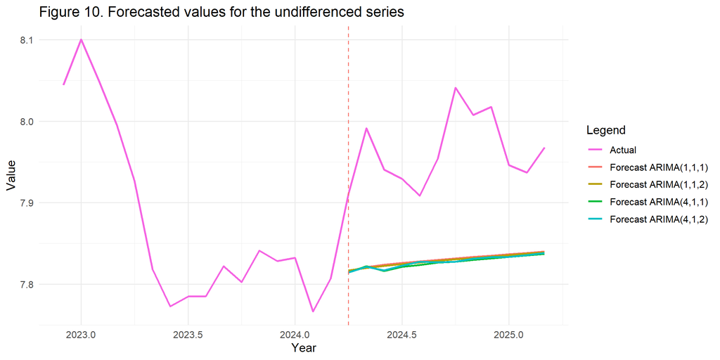

```r
window_start_idx <- max(1, nrow(zinc_df) - (h + 15))

level_plot_df <- bind_rows(
  tibble(
    date = zinc_df$date[window_start_idx:nrow(zinc_df)],
    value = zinc_df$log_price[window_start_idx:nrow(zinc_df)],
    series = "Actual"
  ),
  purrr::imap_dfr(fc_by_model, function(fc_obj, model_name) {
    tibble(
      date = test_dates,
      value = as.numeric(fc_obj$mean),
      series = paste("Forecast", model_name)
    )
  })
) %>%
  mutate(year_num = as_year_decimal(date))

level_colors <- c(
  "Forecast ARIMA(1,1,1)" = "#F8766D",
  "Forecast ARIMA(1,1,2)" = "#B79F00",
  "Forecast ARIMA(4,1,1)" = "#00BA38",
  "Forecast ARIMA(4,1,2)" = "#00BFC4",
  "Actual" = "#F564E3"
)

ggplot(level_plot_df, aes(x = year_num, y = value, color = series)) +
  geom_line(linewidth = 0.9) +
  geom_vline(xintercept = as_year_decimal(min(test_dates)), linetype = "dashed", color = "#F8766D") +
  scale_color_manual(values = level_colors) +
  labs(
    title = "Figure 10. Forecasted values for the undifferenced series",
    x = "Year",
    y = "Value",
    color = "Legend"
  ) +
  theme_minimal(base_size = 12)
```

```r
best_order <- candidate_orders %>%
  filter(model == best_model_name) %>%
  slice(1)

final_fit <- forecast::Arima(
  log_price_ts,
  order = c(best_order$p, best_order$d, best_order$q),
  include.drift = TRUE
)

future_fc <- forecast::forecast(final_fit, h = 12, level = c(80, 95))

last_month <- as.Date(format(max(zinc_df$date), "%Y-%m-01"))
future_dates <- seq(from = last_month, by = "month", length.out = 13)[-1]

forecast_table <- tibble(
  date = future_dates,
  point_forecast = exp(as.numeric(future_fc$mean)),
  lo80 = exp(as.numeric(future_fc$lower[, "80%"])),
  hi80 = exp(as.numeric(future_fc$upper[, "80%"])),
  lo95 = exp(as.numeric(future_fc$lower[, "95%"])),
  hi95 = exp(as.numeric(future_fc$upper[, "95%"]))
)

knitr::kable(
  forecast_table,
  digits = 2,
  caption = "Table 8. ARIMA 12-month forecast in USD"
)
```

Table 8. ARIMA 12-month forecast in USD

| date | point_forecast | lo80 | hi80 | lo95 | hi95 |
| --- | --- | --- | --- | --- | --- |
| 2025-04-01 | 2913.43 | 2697.58 | 3146.56 | 2589.87 | 3277.43 |
| 2025-05-01 | 2926.85 | 2585.54 | 3313.22 | 2421.28 | 3537.99 |
| 2025-06-01 | 2935.47 | 2496.05 | 3452.25 | 2290.72 | 3761.68 |
| 2025-07-01 | 2942.35 | 2422.64 | 3573.56 | 2185.78 | 3960.80 |
| 2025-08-01 | 2948.62 | 2360.69 | 3682.98 | 2098.52 | 4143.10 |
| 2025-09-01 | 2954.67 | 2307.07 | 3784.05 | 2023.87 | 4313.57 |
| 2025-10-01 | 2960.65 | 2259.71 | 3879.02 | 1958.57 | 4475.43 |
| 2025-11-01 | 2966.61 | 2217.19 | 3969.35 | 1900.47 | 4630.86 |
| 2025-12-01 | 2972.58 | 2178.54 | 4056.03 | 1848.06 | 4781.34 |
| 2026-01-01 | 2978.55 | 2143.04 | 4139.79 | 1800.30 | 4927.93 |
| 2026-02-01 | 2984.53 | 2110.19 | 4221.15 | 1756.40 | 5071.42 |
| 2026-03-01 | 2990.53 | 2079.58 | 4300.50 | 1715.76 | 5212.41 |

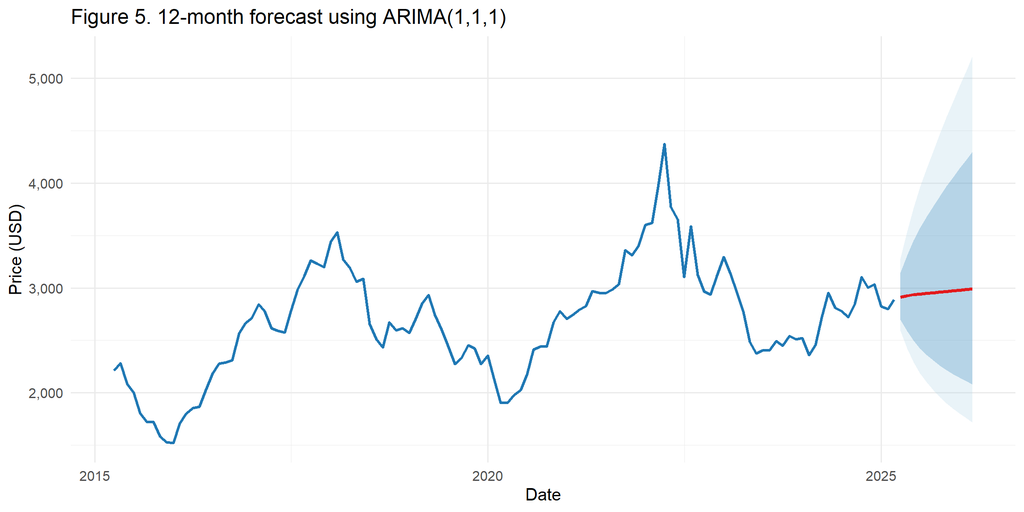

```r
history_tail <- zinc_df %>%
  filter(date >= plot_start_date) %>%
  select(date, price)

ggplot() +
  geom_line(
    data = history_tail,
    aes(x = date, y = price),
    color = "#1f78b4",
    linewidth = 0.9
  ) +
  geom_ribbon(
    data = forecast_table,
    aes(x = date, ymin = lo95, ymax = hi95),
    fill = "#a6cee3",
    alpha = 0.25
  ) +
  geom_ribbon(
    data = forecast_table,
    aes(x = date, ymin = lo80, ymax = hi80),
    fill = "#1f78b4",
    alpha = 0.25
  ) +
  geom_line(
    data = forecast_table,
    aes(x = date, y = point_forecast),
    color = "#e31a1c",
    linewidth = 1
  ) +
  scale_y_continuous(labels = scales::comma) +
  labs(
    title = paste("Figure 5. 12-month forecast using", best_model_name),
    x = "Date",
    y = "Price (USD)"
  ) +
  theme_minimal(base_size = 12)
```

### 1.4 Extrapolative Model and Benchmark

```r
auto_fit <- forecast::auto.arima(train_log, seasonal = FALSE)
auto_fc <- forecast::forecast(auto_fit, h = h)

holt_fit <- forecast::holt(train_log, h = h, damped = TRUE, initial = "optimal")

benchmark_log <- bind_rows(
  calc_metrics(test_log, as.numeric(best_holdout_fc$mean)) %>% mutate(model = best_model_name),
  calc_metrics(test_log, as.numeric(auto_fc$mean)) %>% mutate(model = "auto.arima"),
  calc_metrics(test_log, as.numeric(holt_fit$mean)) %>% mutate(model = "Holt (damped)")
) %>%
  select(model, MAE, RMSE, MAPE, sMAPE) %>%
  arrange(RMSE)

test_level <- exp(test_log)
benchmark_level <- bind_rows(
  calc_metrics(test_level, exp(as.numeric(best_holdout_fc$mean))) %>% mutate(model = best_model_name),
  calc_metrics(test_level, exp(as.numeric(auto_fc$mean))) %>% mutate(model = "auto.arima"),
  calc_metrics(test_level, exp(as.numeric(holt_fit$mean))) %>% mutate(model = "Holt (damped)")
) %>%
  select(model, MAE, RMSE, MAPE, sMAPE) %>%
  arrange(RMSE)

knitr::kable(benchmark_log, digits = 4, caption = "Table 9A. Benchmark comparison (log scale)")
```

Table 9A. Benchmark comparison (log scale)

| model | MAE | RMSE | MAPE | sMAPE |
| --- | --- | --- | --- | --- |
| ARIMA(1,1,1) | 0.1325 | 0.1383 | 1.6618 | 1.6769 |
| auto.arima | 0.1425 | 0.1482 | 1.7872 | 1.8046 |
| Holt (damped) | 0.1554 | 0.1607 | 1.9491 | 1.9695 |

```r
knitr::kable(benchmark_level, digits = 2, caption = "Table 9B. Benchmark comparison (USD levels)")
```

Table 9B. Benchmark comparison (USD levels)

| model | MAE | RMSE | MAPE | sMAPE |
| --- | --- | --- | --- | --- |
| ARIMA(1,1,1) | 358.80 | 376.79 | 12.34 | 13.23 |
| auto.arima | 383.88 | 401.61 | 13.21 | 14.22 |
| Holt (damped) | 415.77 | 432.34 | 14.32 | 15.50 |

**Interpretation (1.4):** The extrapolative model is a useful robustness benchmark, but **ARIMA(1,1,1)** remains the strongest option on holdout performance.

### Chapter I Conclusions

- The zinc price series is effectively non-seasonal and strongly cyclical.
- Log transformation and differencing (`d = 1`) are supported by diagnostics.
- ARIMA outperforms the extrapolative benchmark in this sample.
- Forecast communication in USD levels with confidence bands is ready for RPubs publication.

## RPubs Publishing

1. Knit this report to HTML.
2. In RStudio, click **Publish** and choose **RPubs**.
3. Add metadata and publish.
4. Share the RPubs URL as the chapter deliverable.